# Non-standard Evaluation Tutorial

Amy Lee (@minisciencegirl)

2018-06-28

#### BEFORE

This seems to be a common sentiment when I start googling about non-standard evaluation.

[figure not shown]

#### AFTER

Hopefully, by the end of today’s tutorial, your feelings towards non-standard evaluation will change.

[figure not shown]

### What is non-standard evaluation (NSE)?

> NSE … is a catch-all term that means they don’t follow the usual R rules of evaluation. Instead, they capture the expression that you typed and evaluate it in a custom way. (Programming with dplyr)

So what is standard evaluation? A good analogy that I saw puts it this way: > In standard evaluation R is like a child that receives candy from his grandmother and puts it in his mouth immediately. Every input is evaluated right away. (Edwin Thoen)

Here is an example of standard evaluation:

```r
f <- function(x){ x }

f(2)
```

```
## [1] 2
```

```r
x <- 3

f(x)
```

```
## [1] 3
```

#### Examples of NSE in action

You can see examples of NSE implementation in both base R and tidyverse.

For example, have you ever wondered why you can skip quotes when you call a library?

```r
library("dplyr")
```

If you are feeling lazy, not putting quotes around `dplyr` will also load the package:

```r
library(dplyr)
```

Or how does R know what to put on the x axis and y axis in a plot without you explicitly specifying axis labels?

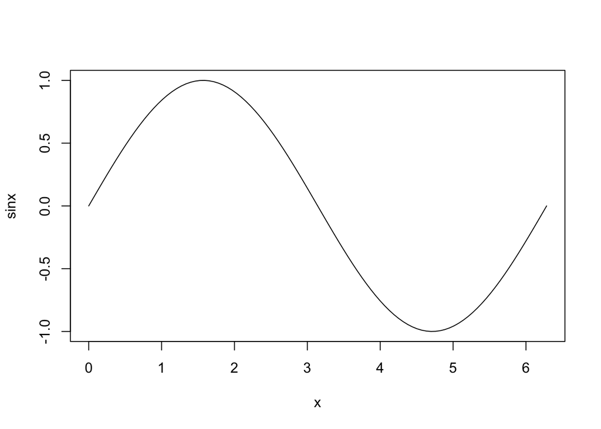

```r
x <- seq(0, 2 * pi, length = 100)
sinx <- sin(x)
plot(x, sinx, type = "l")
```

I am not really going to spend any time talking about NSE implementation in base R today, but rather focusing our discussion on tidyeval, which helps us use tidyverse functions not only for interactive use, but “programmaticatly” (i.e. writing functions).

The major benefit for using NSE in dplyr functions is that you can express operations on data frames succinctly and not have to repeate the name of the dataframe.

- For example, you can write `filter(df, x == 1, y == 2, z == 3)`
- Instead of `df[df$s == 1 & df$y == 2 & df$z == 3, ]`

However, this leads to a whole host of problem when you are trying to program with dplyr functions.

Let’s load tidyverse:

```r
library(tidyverse)
```

### dplyr arguments are not referentially transparent

Most dplyr arguments are not referentially transparent. That means you can’t replace a value with a seemingly equivalent object that you’ve defined elsewhere.

Let’s see what I meant here:

```r
# toy dataframe
df <- tibble(x = 1:3, y = 3:1)

filter(df, x == 1)
```

```
## # A tibble: 1 x 2
##       x     y
##   <int> <int>
## 1     1     3
```

This is not equivalent to this code:

```r
my_var <- x

filter(df, my_var == 1)
```

```
## Error in filter_impl(.data, quo): Result must have length 3, not 100
```

Wait a second, where is it grabbing `x`?

This is also not equivalent to this code:

```r
my_var <- "x"

filter(df, my_var == 1)
```

```
## # A tibble: 0 x 2
## # ... with 2 variables: x <int>, y <int>
```

Furthermore, depending on what variables are defined where, `filter(df, x == y)` could be equivalent to any of:

- `df[df$x == df$y, ]`
- `df[df$x == y, ]`
- `df[x == df$y, ]`
- `df[x == y, ]`

This makes it hard to create functions with arguments that change how dplyr verbs are computed and can make functions more unpredictable than you like.

### tidyeval verbs come to the rescue!

Here are tools for your escape hatch:

- `quo`: quotes its input (i.e. captures R code without evaluation) and captures the current environment
- `enquo`: takes a symbol referring to a function argument, quotes the R code supplied to the argument, captures the envrionemtn where the function was called
- `!!`: unquoting

#### Example: how to vary the grouping variable for a data summarization?

Here is our toy dataframe, `toy.df`

```r
toy.df <- tibble(
  g1 = c(1, 1, 2, 2, 2),
  g2 = c(1, 2, 1, 2, 1),
  a = sample(5),
  b = sample(5)
)
```

And we can group by grouping variable, g1, then calculate mean of a, or group by grouping variable, g2, and so on …

```r
toy.df %>%
  group_by(g1) %>%
  summarise(a = mean(a))
```

```
## # A tibble: 2 x 2
##      g1     a
##   <dbl> <dbl>
## 1    1.    3.
## 2    2.    3.
```

```r
toy.df %>%
  group_by(g2) %>%
  summarise(a = mean(a))
```

```
## # A tibble: 2 x 2
##      g2     a
##   <dbl> <dbl>
## 1    1.  2.33
## 2    2.  4.00
```

OK, what if we want to write a function, `my_summarise`, so that I don’t have to copy and paste the code?

```r
my_summarise <- function(df, group_var) {
  df %>%
    group_by(group_var) %>%
    summarise(a = mean(a))
}

my_summarise(toy.df, g1)
```

```
## Error in grouped_df_impl(data, unname(vars), drop): Column `group_var` is unknown
```

Huh. That didn’t work.

What if I provide the variable name as a string?

```r
my_summarise(toy.df, "g1")
```

```
## Error in grouped_df_impl(data, unname(vars), drop): Column `group_var` is unknown
```

Nope. This still doesn’t work. This is because `group_by` doesn’t evaluate its input, but rather that `group_by` quotes its input.

To make this function work, we need to do two things:

1. we need to quote the input ourselves (which is where the function `enquo()` comes in)
2. and then we need to tell `group_by` not to quote its input because we’ve done it (using `!!`)

```r
my_summarise <- function(df, group_var) {
  group_var <- enquo(group_var)

  df %>%
    group_by(!! group_var) %>%
    summarise(a = mean(a))
}

my_summarise(toy.df, g1)
```

```
## # A tibble: 2 x 2
##      g1     a
##   <dbl> <dbl>
## 1    1.    3.
## 2    2.    3.
```

#### Challenge Question 1

Using the toy dataframe above, `toy.df`, how do you write a second summarise function that calculates the mean, the sum and tally the number of observations?

Hint: Here is how you would perform this interatively

```r
summarise(toy.df, mean = mean(a), sum = sum(a), n = n())
```

```
## # A tibble: 1 x 3
##    mean   sum     n
##   <dbl> <int> <int>
## 1    3.    15     5
```

Answer:

```r
my_summarise2 <- function(df, my_var){
  my_var <- enquo(my_var)

  summarise(df,
            mean = mean(!! my_var),
            sum = sum(!! my_var),
            n = n()
            )
}

my_summarise2(toy.df, a*b)
```

```
## # A tibble: 1 x 3
##    mean   sum     n
##   <dbl> <int> <int>
## 1  7.60    38     5
```